# Homework 02

## Question 1: Training and test error under a fixed design

Consider a linear regression problem with $n=100$ observations and $q=20$ available covariates. Generate one matrix $\mathbf X_{\mathrm{all}}\in\mathbb R^{n\times q}$ whose entries are independent $\mathcal N(0,1)$ random variables, and then keep this realized matrix fixed. Let

$$\beta_k=0.4^{\sqrt{k}},
\qquad k=1,\ldots,q,$$

and define

$$\boldsymbol\mu=\mathbf X_{\mathrm{all}}\boldsymbol\beta.$$

Generate one training response and one independent test response from

$$\begin{aligned}
\mathbf y
&=\boldsymbol\mu+\boldsymbol\epsilon,\\
\mathbf y^*
&=\boldsymbol\mu+\boldsymbol\epsilon^*,
\end{aligned}$$

where

$$\boldsymbol\epsilon,\boldsymbol\epsilon^*
\overset{\mathrm{ind}}{\sim}
\mathcal N_n(\mathbf 0,\mathbf I_n).$$

Here $\mathbf I_n$ is the $n\times n$ identity matrix.

For $j=0,1,\ldots,q$, fit a linear model with an intercept and the first $j$ columns of $\mathbf X_{\mathrm{all}}$ using $\mathbf y$. If $\widehat{\boldsymbol\mu}_j$ is its fitted mean vector, define

$$\operatorname{MSE}_{\mathrm{train},j}
=\frac{1}{n}
\left\lVert
\mathbf y-\widehat{\boldsymbol\mu}_j
\right\rVert_2^2,$$

and

$$\operatorname{MSE}_{\mathrm{test},j}
=\frac{1}{n}
\left\lVert
\mathbf y^*-\widehat{\boldsymbol\mu}_j
\right\rVert_2^2.$$

Repeat this process independently 200 times, keeping $\mathbf X_{\mathrm{all}}$ fixed.

Use seed `43202` before generating $\mathbf X_{\mathrm{all}}$ and the response errors. R and Python use different random-number generators, so their exact numerical values need not agree.

1. For each $j$, calculate the average training and test MSE over the 200 simulation runs. Plot both curves against $j$. Verify numerically that training MSE does not increase as predictors are added in each simulation run.

**Answer.** I generated the design once and kept that design and its mean vector fixed while I repeated the training and test calculations 200 times.

**Show the starter code**

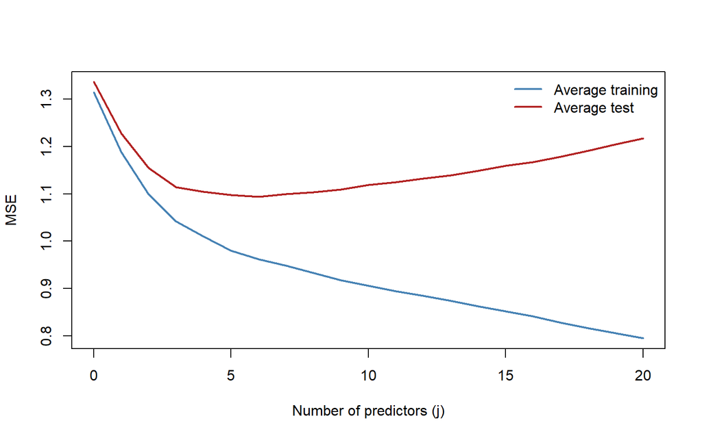

Average training and test MSE over 200 simulations.

```r
set.seed(43202)

n <- 100
q <- 20
n_sim <- 200

X_all <- matrix(rnorm(n * q), nrow = n, ncol = q)
beta <- 0.4^sqrt(seq_len(q))
mu <- drop(X_all %*% beta)

make_design <- function(j) {
  if (j == 0) {
    matrix(1, nrow = n, ncol = 1)
  } else {
    cbind(1, X_all[, seq_len(j), drop = FALSE])
  }
}

designs <- lapply(0:q, make_design)
qr_fits <- lapply(designs, qr)
train_mse <- matrix(NA_real_, nrow = n_sim, ncol = q + 1)
test_mse <- matrix(NA_real_, nrow = n_sim, ncol = q + 1)

for (s in seq_len(n_sim)) {
  y <- mu + rnorm(n)
  y_test <- mu + rnorm(n)

  for (j in 0:q) {
    fitted_j <- qr.fitted(qr_fits[[j + 1]], y)
    train_mse[s, j + 1] <- mean((y - fitted_j)^2)
    test_mse[s, j + 1] <- mean((y_test - fitted_j)^2)
  }
}

avg_train <- colMeans(train_mse)
avg_test <- colMeans(test_mse)

plot(
  0:q, avg_train,
  type = "l", lwd = 2, col = "steelblue",
  ylim = range(avg_train, avg_test),
  xlab = "Number of predictors (j)", ylab = "MSE"
)
lines(0:q, avg_test, lwd = 2, col = "firebrick")
legend(
  "topright", c("Average training", "Average test"),
  col = c("steelblue", "firebrick"), lwd = 2, bty = "n"
)
```

**Show the starter code**

```r
q1a_results <- data.frame(
  j = 0:q,
  average_training_MSE = avg_train,
  average_test_MSE = avg_test
)
round(q1a_results, 4)
```

```
    j average_training_MSE average_test_MSE
1   0               1.3147           1.3367
2   1               1.1881           1.2279
3   2               1.0986           1.1546
4   3               1.0415           1.1144
5   4               1.0105           1.1046
6   5               0.9806           1.0979
7   6               0.9623           1.0940
8   7               0.9481           1.0995
9   8               0.9327           1.1034
10  9               0.9173           1.1096
11 10               0.9061           1.1186
12 11               0.8948           1.1251
13 12               0.8846           1.1325
14 13               0.8744           1.1390
15 14               0.8625           1.1489
16 15               0.8524           1.1594
17 16               0.8409           1.1675
18 17               0.8279           1.1786
19 18               0.8166           1.1910
20 19               0.8052           1.2052
21 20               0.7948           1.2170
```

**Show the starter code**

```r
training_is_monotone <- apply(
  train_mse, 1,
  function(z) all(diff(z) <= 1e-10)
)
c(
  runs_checked = length(training_is_monotone),
  runs_nonincreasing = sum(training_is_monotone)
)
```

```
      runs_checked runs_nonincreasing
               200                200
```

All 200 training-error curves were nonincreasing. This is also what should happen for nested least-squares fits: adding a predictor expands the space over which RSS is minimized, so the new RSS cannot be larger.

2. For the model containing the first $j$ predictors, write

$$\mathbf X_j
=
[\mathbf 1,\mathbf x_1,\ldots,\mathbf x_j],
\qquad
\mathbf H_j
=
\mathbf X_j
(\mathbf X_j^{\mathsf T}\mathbf X_j)^{-1}
\mathbf X_j^{\mathsf T}.$$

Let $p_j=j+1$ be its fitted mean-parameter count, including the intercept. Define its **total squared approximation bias** as

$$B_j^2
=\left\lVert
(\mathbf I_n-\mathbf H_j)\boldsymbol\mu
\right\rVert_2^2.$$

Thus, $B_j^2/n$ is the mean squared approximation bias.

Calculate the two theoretical expectations

$$E\!\left(
\operatorname{MSE}_{\mathrm{train},j}
\mid \mathbf X_{\mathrm{all}}
\right)
=\frac{B_j^2}{n}+1-\frac{p_j}{n},$$

and

$$E\!\left(
\operatorname{MSE}_{\mathrm{test},j}
\mid \mathbf X_{\mathrm{all}}
\right)
=\frac{B_j^2}{n}+1+\frac{p_j}{n}.$$

Add these expectations to your plot and compare them with the simulation averages.

**Answer.** I projected the fixed true mean vector onto each model space to calculate $B_j^2$. Here $p_j=j+1$ because every model includes an intercept.

**Show the starter code**

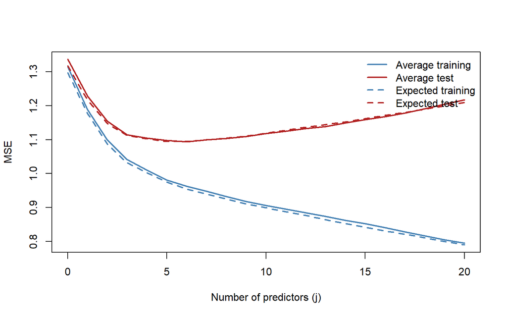

Simulation averages and conditional theoretical MSEs.

```r
bias_squared <- vapply(
  seq_along(qr_fits),
  function(m) {
    fitted_mean <- qr.fitted(qr_fits[[m]], mu)
    sum((mu - fitted_mean)^2)
  },
  numeric(1)
)

p_j <- 1:(q + 1)
theory_train <- bias_squared / n + 1 - p_j / n
theory_test <- bias_squared / n + 1 + p_j / n

plot(
  0:q, avg_train,
  type = "l", lwd = 2, col = "steelblue",
  ylim = range(avg_train, avg_test, theory_train, theory_test),
  xlab = "Number of predictors (j)", ylab = "MSE"
)
lines(0:q, avg_test, lwd = 2, col = "firebrick")
lines(0:q, theory_train, lwd = 2, lty = 2, col = "steelblue")
lines(0:q, theory_test, lwd = 2, lty = 2, col = "firebrick")
legend(
  "topright",
  c("Average training", "Average test",
    "Expected training", "Expected test"),
  col = c("steelblue", "firebrick", "steelblue", "firebrick"),
  lwd = 2, lty = c(1, 1, 2, 2), bty = "n"
)
```

**Show the starter code**

```r
q1b_results <- data.frame(
  j = 0:q,
  average_training_MSE = avg_train,
  expected_training_MSE = theory_train,
  average_test_MSE = avg_test,
  expected_test_MSE = theory_test
)
round(q1b_results, 4)
```

```
    j average_training_MSE expected_training_MSE average_test_MSE
1   0               1.3147                1.2974           1.3367
2   1               1.1881                1.1763           1.2279
3   2               1.0986                1.0872           1.1546
4   3               1.0415                1.0319           1.1144
5   4               1.0105                1.0022           1.1046
6   5               0.9806                0.9750           1.0979
7   6               0.9623                0.9547           1.0940
8   7               0.9481                0.9395           1.0995
9   8               0.9327                0.9243           1.1034
10  9               0.9173                0.9105           1.1096
11 10               0.9061                0.8992           1.1186
12 11               0.8948                0.8878           1.1251
13 12               0.8846                0.8764           1.1325
14 13               0.8744                0.8640           1.1390
```

[output cut: 29 more lines]

**Show the starter code**

```r
c(
  largest_training_difference = max(abs(avg_train - theory_train)),
  largest_test_difference = max(abs(avg_test - theory_test))
)
```

```
largest_training_difference     largest_test_difference
                 0.01723885                  0.01929096
```

The simulation averages are close to their conditional expectations. The small differences are reasonable Monte Carlo error from using 200 runs. The expected test curve first falls as approximation bias is removed and then rises as estimation variance becomes more important, while the expected training curve keeps falling.

3. Add the test MSE curve from one simulation run to the plot. Explain why this single curve is less smooth than the average test MSE. Use the approximation-bias and estimation-variance terms in the expected test MSE to explain why training MSE cannot be used by itself to select the predictor count.

**Answer.**

**Show the starter code**

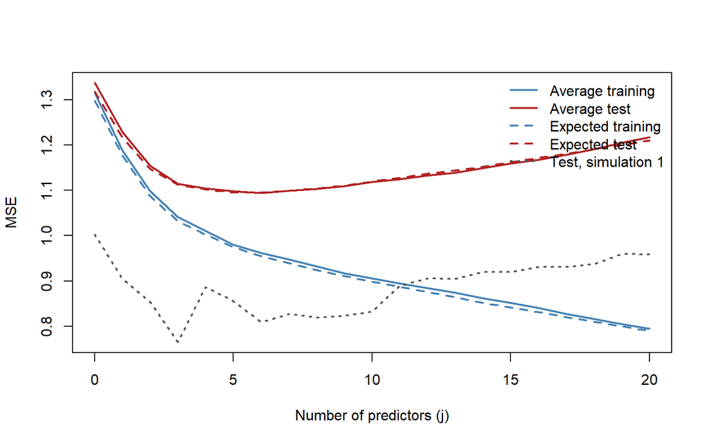

One test-error curve compared with the averages and expectations.

```r
plot(
  0:q, avg_train,
  type = "l", lwd = 2, col = "steelblue",
  ylim = range(avg_train, avg_test, theory_train, theory_test, test_mse[1, ]),
  xlab = "Number of predictors (j)", ylab = "MSE"
)
lines(0:q, avg_test, lwd = 2, col = "firebrick")
lines(0:q, theory_train, lwd = 2, lty = 2, col = "steelblue")
lines(0:q, theory_test, lwd = 2, lty = 2, col = "firebrick")
lines(0:q, test_mse[1, ], lwd = 2, lty = 3, col = "gray35")
legend(
  "topright",
  c("Average training", "Average test", "Expected training",
    "Expected test", "Test, simulation 1"),
  col = c("steelblue", "firebrick", "steelblue", "firebrick", "gray35"),
  lwd = 2, lty = c(1, 1, 2, 2, 3), bty = "n"
)
```

The single test curve is noisier because it comes from only one pair of training and test response vectors. Averaging 200 independent runs reduces that noise. For expected test MSE, $B_j^2/n$ usually falls as predictors are added, but the $+p_j/n$ estimation-variance term grows. Expected training MSE contains the $-p_j/n$ term, while observed training MSE cannot increase for these nested least-squares fits. Training error therefore favors extra flexibility, even when that flexibility is fitting noise, so it cannot capture the bias–variance tradeoff needed to choose $j$ by itself.

## Question 2: Prediction error at one target point

Let $n=100$, $q=6$, and $\sigma^2=1$. Construct the fixed covariate matrix $\mathbf X_{\mathrm{all}}\in\mathbb R^{n\times q}$ with entries

$$(\mathbf X_{\mathrm{all}})_{ik}
=\sqrt{2}\cos\left\{
\frac{\pi k(i-\tfrac12)}{n}
\right\},
\qquad
i=1,\ldots,n,
\quad
k=1,\ldots,q.$$

Its columns satisfy

$$\mathbf 1^{\mathsf T}\mathbf X_{\mathrm{all}}=\mathbf 0^{\mathsf T},
\qquad
\frac{1}{n}\mathbf X_{\mathrm{all}}^{\mathsf T}\mathbf X_{\mathrm{all}}=\mathbf I_q.$$

Here $\mathbf I_q$ is the $q\times q$ identity matrix.

The following code shows a direct construction of $\mathbf X_{\mathrm{all}}$.

**R**

**Show the starter code**

```r
n <- 100
q <- 6
X_all <- outer(
  1:n, 1:q,
  function(i, k) sqrt(2) * cos(pi * k * (i - 0.5) / n)
)
```

**Python**

**Show the starter code**

```python
import numpy as np

n, q = 100, 6
i = np.arange(1, n + 1)[:, None]
k = np.arange(1, q + 1)[None, :]
X_all = np.sqrt(2) * np.cos(np.pi * k * (i - 0.5) / n)
```

Keep $\mathbf X_{\mathrm{all}}$ fixed and generate one training response from

$$\mathbf y
=\mathbf X_{\mathrm{all}}\boldsymbol\beta+\boldsymbol\epsilon,
\qquad
\boldsymbol\beta
=(0.5,0.5,0.5,0.5,0.5,0.5)^{\mathsf T},$$

where

$$\boldsymbol\epsilon
\sim
\mathcal N_n(\mathbf 0,\mathbf I_n).$$

Here $\mathbf I_n$ is the $n\times n$ identity matrix.

For $j=0,\ldots,6$, fit a linear model with an intercept and the first $j$ predictors. Consider prediction of the mean response at

$$\mathbf x_0=(0,1,0,0,1,0)^{\mathsf T}.$$

Write

$$\mu_0=\mathbf x_0^{\mathsf T}\boldsymbol\beta,$$

and let $\widehat\mu_{0,j}$ be the prediction from the model containing the first $j$ predictors. Here $x_{0k}$ denotes the $k$th coordinate of $\mathbf x_0$. For this design,

$$E\!\left[
\left(\widehat\mu_{0,j}-\mu_0\right)^2
\mid \mathbf X_{\mathrm{all}}
\right]
=
\left(
\sum_{k=j+1}^{q}x_{0k}\beta_k
\right)^2
+\frac{\sigma^2}{n}
\left(
1+\sum_{k=1}^{j}x_{0k}^2
\right).$$

1. Calculate $\mu_0$ and the theoretical expected squared error for $j=0,\ldots,6$. Identify the values of $j$ where this error changes and where it remains unchanged.

**Answer.** Here the goal is to estimate the mean response at one fixed target covariate vector, not to predict a new noisy response $y_0^*$. Question 1 instead uses test MSE averaged over all rows of the design. Since only coordinates 2 and 5 of $\mathbf x_0$ are nonzero, $\mu_0=0.5+0.5=1$.

**Show the starter code**

```r
n2 <- 100
q2 <- 6
i2 <- seq_len(n2)
X_all2 <- outer(
  i2, seq_len(q2),
  function(i, k) sqrt(2) * cos(pi * k * (i - 0.5) / n2)
)
beta2 <- rep(0.5, q2)
x0 <- c(0, 1, 0, 0, 1, 0)
mu0 <- sum(x0 * beta2)

theory_point_error <- sapply(0:q2, function(j) {
  omitted_part <- if (j < q2) {
    sum(x0[(j + 1):q2] * beta2[(j + 1):q2])
  } else {
    0
  }
  included_squares <- if (j > 0) sum(x0[seq_len(j)]^2) else 0
  omitted_part^2 + (1 / n2) * (1 + included_squares)
})

q2a_results <- data.frame(
  j = 0:q2,
  mu0 = mu0,
  expected_squared_error = theory_point_error
)
q2a_results
```

```
  j mu0 expected_squared_error
1 0   1                   1.01
2 1   1                   1.01
3 2   1                   0.27
4 3   1                   0.27
5 4   1                   0.27
6 5   1                   0.03
7 6   1                   0.03
```

The error is $1.01$ for $j=0,1$, drops to $0.27$ for $j=2,3,4$, and drops again to $0.03$ for $j=5,6$. It changes when predictor 2 and predictor 5 enter. Adding predictors 1, 3, 4, or 6 does not change it because their target coordinates are zero.

2. Use seed `43203`. Generate the response, fit the models, and calculate

$$\left(\widehat\mu_{0,j}-\mu_0\right)^2.$$

Repeat this independently 200 times. Plot the simulation averages and theoretical expectations together. Report the smallest $j$ that minimizes the theoretical error.

**Answer.**

**Show the starter code**

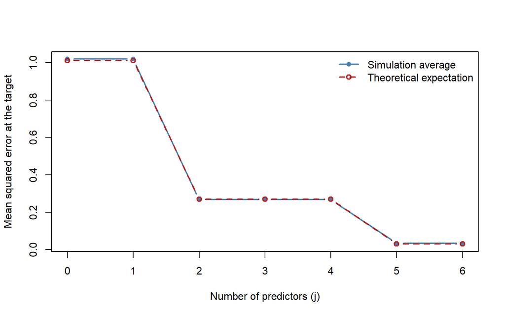

Mean squared error for estimating the mean response at x0.

```r
set.seed(43203)

designs2 <- lapply(0:q2, function(j) {
  if (j == 0) {
    matrix(1, nrow = n2, ncol = 1)
  } else {
    cbind(1, X_all2[, seq_len(j), drop = FALSE])
  }
})
qr_fits2 <- lapply(designs2, qr)
point_squared_error <- matrix(NA_real_, nrow = 200, ncol = q2 + 1)

for (s in seq_len(200)) {
  y2 <- drop(X_all2 %*% beta2) + rnorm(n2)

  for (j in 0:q2) {
    coef_j <- qr.coef(qr_fits2[[j + 1]], y2)
    target_j <- c(1, x0[seq_len(j)])
    prediction_j <- sum(target_j * coef_j)
    point_squared_error[s, j + 1] <- (prediction_j - mu0)^2
  }
}

average_point_error <- colMeans(point_squared_error)
plot(
  0:q2, average_point_error,
  type = "b", pch = 16, lwd = 2, col = "steelblue",
  ylim = range(average_point_error, theory_point_error),
  xlab = "Number of predictors (j)",
  ylab = "Mean squared error at the target"
)
lines(
  0:q2, theory_point_error,
  type = "b", pch = 1, lwd = 2, lty = 2, col = "firebrick"
)
legend(
  "topright", c("Simulation average", "Theoretical expectation"),
  col = c("steelblue", "firebrick"), pch = c(16, 1),
  lwd = 2, lty = c(1, 2), bty = "n"
)
```

**Show the starter code**

```r
round(data.frame(
  j = 0:q2,
  simulation_average = average_point_error,
  theoretical_expectation = theory_point_error
), 4)
```

```
  j simulation_average theoretical_expectation
1 0             1.0189                    1.01
2 1             1.0189                    1.01
3 2             0.2671                    0.27
4 3             0.2671                    0.27
5 4             0.2671                    0.27
6 5             0.0338                    0.03
7 6             0.0338                    0.03
```

The simulation averages are close to the theoretical values. The minimum theoretical error is $0.03$, attained at $j=5$ and $j=6$, so the smallest minimizing value is $j=5$.

3. All six regression coefficients are nonzero. Explain why only predictors 2 and 5 contribute directly to the mean response at $\mathbf x_0$. Contrast this target-specific error with the test MSE averaged over all rows of $\mathbf X_{\mathrm{all}}$ in Question 1.

**Answer.** A predictor contributes directly to $\mu_0=\sum_k x_{0k}\beta_k$ only when its coordinate at the target point is nonzero. Here $x_{02}=x_{05}=1$ and the other four coordinates are zero, so only predictors 2 and 5 contribute even though all six coefficients are nonzero. The error here is specific to one covariate vector, so its bias and variance depend on that vector. Question 1’s test MSE averages squared errors across all 100 design rows, where every predictor varies and can affect prediction performance.

## Question 3: The optimism correction

Choose one candidate model before observing the response. Let $\mathbf X\in\mathbb R^{n\times p}$ be its full-rank design matrix, including the intercept, and let

$$\mathbf H
=\mathbf X
(\mathbf X^{\mathsf T}\mathbf X)^{-1}
\mathbf X^{\mathsf T}$$

be its hat matrix. Suppose

$$\mathbf y=\boldsymbol\mu+\boldsymbol\epsilon,
\qquad
\mathbf y^*=\boldsymbol\mu+\boldsymbol\epsilon^*,$$

Conditional on the fixed design $\mathbf X$, the two error vectors are independent, have mean zero, and have covariance matrix $\sigma^2\mathbf I_n$. Define

$$\operatorname{MSE}_{\mathrm{train}}
=
\frac{1}{n}
\left\lVert
\mathbf y-\mathbf H\mathbf y
\right\rVert_2^2,
\qquad
\operatorname{MSE}_{\mathrm{test}}
=
\frac{1}{n}
\left\lVert
\mathbf y^*-\mathbf H\mathbf y
\right\rVert_2^2.$$

The conditional bias vector of the fitted mean is

$$E(\mathbf H\mathbf y\mid\mathbf X)-\boldsymbol\mu
=
-(\mathbf I_n-\mathbf H)\boldsymbol\mu.$$

Let $B^2$ denote the **total squared approximation bias**:

$$B^2
=\left\lVert
(\mathbf I_n-\mathbf H)\boldsymbol\mu
\right\rVert_2^2.$$

Thus, $B^2/n$ is the mean squared approximation bias.

You may use

$$\mathbf H^{\mathsf T}=\mathbf H,
\qquad
\mathbf H^2=\mathbf H,
\qquad
\operatorname{tr}(\mathbf H)=p.$$

For any fixed matrix $\mathbf A$, you may also use

$$E\!\left(
\boldsymbol\epsilon^{\mathsf T}
\mathbf A
\boldsymbol\epsilon
\mid \mathbf X
\right)
=\sigma^2\operatorname{tr}(\mathbf A).$$

1. Derive

$$E(\operatorname{MSE}_{\mathrm{train}}\mid\mathbf X)
=\frac{B^2}{n}
+\sigma^2\left(1-\frac{p}{n}\right),$$

and

$$E(\operatorname{MSE}_{\mathrm{test}}\mid\mathbf X)
=\frac{B^2}{n}
+\sigma^2\left(1+\frac{p}{n}\right).$$

**Answer.** Let $\mathbf M=\mathbf I_n-\mathbf H$. For training error,

$$\mathbf y-\mathbf H\mathbf y
=\mathbf M\boldsymbol\mu+\mathbf M\boldsymbol\epsilon.$$

The cross term has conditional expectation zero. Also, symmetry and idempotence of $\mathbf H$ give $\mathbf M^{\mathsf T}\mathbf M=\mathbf M$. Therefore,

$$\begin{aligned}
E\!\left(\lVert\mathbf y-\mathbf H\mathbf y\rVert^2\mid\mathbf X\right)
&=B^2+
E\!\left(\boldsymbol\epsilon^{\mathsf T}\mathbf M
\boldsymbol\epsilon\mid\mathbf X\right)\\
&=B^2+\sigma^2\operatorname{tr}(\mathbf I_n-\mathbf H)\\
&=B^2+\sigma^2(n-p).
\end{aligned}$$

Dividing by $n$ gives

$$E(\operatorname{MSE}_{\mathrm{train}}\mid\mathbf X)
=\frac{B^2}{n}+\sigma^2\left(1-\frac pn\right).$$

For test error,

$$\mathbf y^*-\mathbf H\mathbf y
=\mathbf M\boldsymbol\mu+\boldsymbol\epsilon^*-
\mathbf H\boldsymbol\epsilon.$$

All cross terms have conditional expectation zero because the errors have mean zero and $\boldsymbol\epsilon^*$ is independent of $\boldsymbol\epsilon$. Using $\mathbf H^{\mathsf T}\mathbf H=\mathbf H$,

$$\begin{aligned}
E\!\left(\lVert\mathbf y^*-\mathbf H\mathbf y\rVert^2\mid\mathbf X\right)
&=B^2+n\sigma^2+
\sigma^2\operatorname{tr}(\mathbf H)\\
&=B^2+\sigma^2(n+p).
\end{aligned}$$

Dividing by $n$ gives

$$E(\operatorname{MSE}_{\mathrm{test}}\mid\mathbf X)
=\frac{B^2}{n}+\sigma^2\left(1+\frac pn\right).$$

2. Deduce the expected optimism, defined as $E(\operatorname{MSE}_{\mathrm{test}}-\operatorname{MSE}_{\mathrm{train}}\mid\mathbf X)$. For

$$n=120,
\qquad
p=5,
\qquad
\frac{B^2}{n}=0.04,
\qquad
\sigma^2=1,$$

calculate the expected training MSE, expected test MSE, and their difference. Explain why the ordering need not hold for every realized pair of responses.

**Answer.** Subtracting the two expectations cancels the approximation-bias term and gives

$$E(\operatorname{MSE}_{\mathrm{test}}-
\operatorname{MSE}_{\mathrm{train}}\mid\mathbf X)
=\frac{2p\sigma^2}{n}.$$

For the given values,

$$\begin{aligned}
E(\operatorname{MSE}_{\mathrm{train}}\mid\mathbf X)
&=0.04+1\left(1-\frac{5}{120}\right)
=0.9983,\\
E(\operatorname{MSE}_{\mathrm{test}}\mid\mathbf X)
&=0.04+1\left(1+\frac{5}{120}\right)
=1.0817,\\
E(\operatorname{MSE}_{\mathrm{test}}-
\operatorname{MSE}_{\mathrm{train}}\mid\mathbf X)
&=\frac{10}{120}=0.0833.
\end{aligned}$$

This is an ordering of expectations, not a guarantee for each data realization. A realized training MSE and test MSE contain random quadratic and cross terms, so a particular independent test response can happen to have the smaller MSE.

3. Continue with $n=120$ and $p=5$. Suppose the candidate model has residual sum of squares $\operatorname{RSS}=116.4$, and suppose a common estimate of the error variance is $\widehat\sigma^2=0.96$.

Calculate

$$\widehat{\operatorname{MSE}}_{\mathrm{test}}
=\frac{
\operatorname{RSS}+2p\widehat\sigma^2
}{n},$$

and

$$C_p
=\frac{\operatorname{RSS}}{\widehat\sigma^2}
-n+2p.$$

Show how these two quantities are related, and explain why minimizing $C_p$ is equivalent to minimizing the corrected test MSE when $n$ and $\widehat\sigma^2$ are common to all candidate models.

**Answer.** The corrected estimate is

$$\widehat{\operatorname{MSE}}_{\mathrm{test}}
=\frac{116.4+2(5)(0.96)}{120}
=\frac{126}{120}=1.05.$$

Also,

$$C_p=\frac{116.4}{0.96}-120+2(5)
=121.25-120+10=11.25.$$

Rearranging the definition of $C_p$ shows the connection:

$$\widehat{\operatorname{MSE}}_{\mathrm{test}}
=\frac{\widehat\sigma^2(C_p+n)}{n}
=\widehat\sigma^2\left(1+\frac{C_p}{n}\right).$$

When $n$ and $\widehat\sigma^2$ are the same for every candidate, this is an increasing linear function of $C_p$. Thus, the model that minimizes $C_p$ also minimizes the corrected test MSE.

## Question 4: Comparing Mallows’ $C_p$, AIC, and BIC

Use `data/diabetes.csv`, with `y` as the response. Use rows 1 through 370 as the training data, and let $n=370$ denote the training sample size. Do not use rows 371 through 442 in this question. Fit the following ordinary least-squares models, each with an intercept.

| Model | Predictors | $p$ |
| --- | --- | --- |
| Model A | `bmi`, `bp`, `s5`, `sex`, `s1`, `s2`, `s4` | 8 |
| Model B | all predictors in Model A, followed by `s6` | 9 |
| Full reference | all ten predictors | 11 |

Here $p$ counts fitted mean parameters, including the intercept. Estimate one common noise variance from the full reference model:

$$\widehat\sigma^2_{\mathrm{full}}
=\frac{\operatorname{RSS}_{\mathrm{full}}}{n-11}.$$

For Models A and B, calculate

$$C_p
=\frac{\operatorname{RSS}}{\widehat\sigma^2_{\mathrm{full}}}
-n+2p,$$

$$\operatorname{AIC}^{\mathrm{red}}
=n\log\left(\frac{\operatorname{RSS}}{n}\right)+2p,$$

and

$$\operatorname{BIC}^{\mathrm{red}}
=n\log\left(\frac{\operatorname{RSS}}{n}\right)
+p\log(n).$$

The reduced AIC and BIC omit constants shared by the two candidate models. Smaller values are preferred within each criterion.

1. Fit the three models. Report $p$, RSS, the residual degrees of freedom of the full model, and $\widehat\sigma^2_{\mathrm{full}}$.

**Answer.** This question compares fit improvements with complexity penalties. I used only the specified 370 training rows.

**Show the starter code**

```r
diabetes <- read.csv("data/diabetes.csv")
training <- diabetes[1:370, ]
n_train <- nrow(training)

model_A <- lm(
  y ~ bmi + bp + s5 + sex + s1 + s2 + s4,
  data = training
)
model_B <- lm(
  y ~ bmi + bp + s5 + sex + s1 + s2 + s4 + s6,
  data = training
)
full_reference <- lm(
  y ~ age + sex + bmi + bp + s1 + s2 + s3 + s4 + s5 + s6,
  data = training
)

model_list <- list(
  "Model A" = model_A,
  "Model B" = model_B,
  "Full reference" = full_reference
)
p_values <- c(8, 9, 11)
rss_values <- vapply(model_list, deviance, numeric(1))
full_residual_df <- df.residual(full_reference)
sigma2_full <- rss_values[["Full reference"]] / full_residual_df

data.frame(
  Model = names(model_list),
  p = p_values,
  RSS = round(rss_values, 3),
  row.names = NULL
)
```

```
           Model  p     RSS
1        Model A  8 1098909
2        Model B  9 1089717
3 Full reference 11 1089452
```

**Show the starter code**

```r
c(
  full_model_residual_df = full_residual_df,
  sigma2_full = sigma2_full
)
```

```
full_model_residual_df            sigma2_full
               359.000               3034.684
```

The full model has 359 residual degrees of freedom and gives $\widehat\sigma^2_{\mathrm{full}}=3034.684$. The RSS values are $1098908.566$ for Model A, $1089717.057$ for Model B, and $1089451.721$ for the full reference model.

2. Calculate $C_p$, reduced AIC, and reduced BIC for Models A and B. State which model each criterion selects. Do not compare numerical values across different criteria.

**Answer.**

**Show the starter code**

```r
candidate_rss <- rss_values[c("Model A", "Model B")]
candidate_p <- p_values[1:2]

criteria <- data.frame(
  Model = c("Model A", "Model B"),
  p = candidate_p,
  RSS = unname(candidate_rss),
  Cp = unname(candidate_rss / sigma2_full - n_train + 2 * candidate_p),
  AIC_reduced = unname(
    n_train * log(candidate_rss / n_train) + 2 * candidate_p
  ),
  BIC_reduced = unname(
    n_train * log(candidate_rss / n_train) + candidate_p * log(n_train)
  )
)

criteria_to_show <- criteria
criteria_to_show[, 3:6] <- round(criteria_to_show[, 3:6], 3)
criteria_to_show
```

```
    Model p     RSS    Cp AIC_reduced BIC_reduced
1 Model A 8 1098909 8.116    2974.640    3005.948
2 Model B 9 1089717 7.087    2973.532    3008.754
```

$C_p$ is 8.116 for Model A and 7.087 for Model B, so $C_p$ selects Model B. Reduced AIC is 2974.640 for Model A and 2973.532 for Model B, so AIC also selects Model B. Reduced BIC is 3005.948 for Model A and 3008.754 for Model B, so BIC selects Model A. Each comparison is made only within its own criterion.

3. Compare the improvement in fit from adding `s6` with the one-parameter penalty under each criterion. Use this comparison to explain any disagreement. Why does selecting a model not establish that it is the true data-generating model?

**Answer.** Adding `s6` lowers RSS by $1098908.566-1089717.057=9191.509$. For $C_p$, this lowers the fit part by $9191.509/3034.684=3.029$, which is larger than the extra penalty of 2. Thus, $C_p$ decreases and favors Model B.

For AIC and BIC, the decrease in the log-RSS part is

$$370\log\left(\frac{1098908.566}{1089717.057}\right)=3.108.$$

This improvement is larger than AIC’s one-parameter penalty of 2, so AIC favors Model B. It is smaller than BIC’s penalty of $\log(370)=5.914$, so BIC favors Model A. The criteria disagree because BIC penalizes the added parameter more strongly.

Selecting a model only says which candidate has the best penalized fit under that criterion and sample. It does not rule out omitted structure, guarantee the regression assumptions, or remove sampling variability, so it does not prove that the selected model generated the data.

## Question 5: Validation and final test data

Use rows 1 through 370 of `diabetes.csv` as the training data and rows 371 through 442 as the final test data. Consider eleven nested candidate models. For $j=0,1,\ldots,10$, the model with $j$ predictors contains an intercept and the first $j$ predictors in this order:

`age`, `sex`, `bmi`, `bp`, `s1`, `s2`, `s3`, `s4`, `s5`, `s6`.

An analyst proposes the following procedure:

1. Fit all eleven candidate models using the training data.
2. Calculate the MSE of each model on the final test data.
3. Select the model with the smallest test MSE.
4. Report that minimum as the final estimate of prediction error.

The analyst argues that the procedure is valid because the final test data were not used to estimate the regression coefficients.

1. Identify the first step that misuses the final test data. Explain why the minimum of eleven test MSE values is generally too favorable as an estimate of the selected procedure’s future prediction error.

**Answer.** The misuse starts in Step 2, when the analyst exposes the final-test performance of all eleven candidates before choosing a model. Calculating a test MSE would be a valid final evaluation only after one procedure had already been fixed. Although the coefficients were estimated without the test rows, choosing $j$ from the eleven exposed values tunes the procedure to random features of that test set. The minimum is likely to come from a model whose test error had a favorable random fluctuation, so that same minimum is generally biased downward as an estimate of the selected procedure’s error on new data.

2. Rewrite the analysis using five-fold cross-validation within the training data. State how the predictor count is selected, what is refitted, and when the final test data may be used.

**Answer.** First divide rows 1–370 into five folds, record the random seed, and use the same folds for every candidate. For each $j=0,\ldots,10$, fit the model on four folds and predict the held-out fold. Compute the validation MSE for each fold and average the five validation MSE values for each predictor count. Any data-dependent preprocessing, variable selection, or tuning must also be repeated using only the four training folds in that iteration, without using the held-out fold. Select the predictor count with the smallest average validation MSE and refit that model using all 370 training rows. Then use rows 371–442 once to report the final test MSE, without revising any choices after seeing the result.

3. Suppose the analyst has already examined all eleven test MSE values. What can still be reported transparently, and what additional data would be needed for a new final evaluation?

**Answer.** The analyst can report all eleven observed test MSE values, the rule used to choose their minimum, and clearly label the comparison and minimum as exploratory and selection-biased. They can also report the cross-validation results from the training data, while disclosing that the original test set was already examined. A new final evaluation requires a fresh independent test sample from the same target population that is not used for any further model choice or tuning.